# Modélisation et prédiction du prix des Airbnb au Québec

Alexandre Richard

29/07/2021

```r
library(corrplot)
library(RColorBrewer)
library(dismo)
library(ranger)
```

## Chargement des données

```r
data <- read.csv("listings.csv",encoding = "UTF-8")
```

## Traitement de données

Suppression de variables non utiles.

```r
data <- data[,c(30:34,36:38,40:42,56,61:67)]
```

Exploration de données.

```r
summary(data$longitude)
```

```
##    Min. 1st Qu.  Median    Mean 3rd Qu.    Max.
##  -71.45  -71.24  -71.23  -71.24  -71.22  -71.15
```

```r
summary(data$latitude)
```

```
##    Min. 1st Qu.  Median    Mean 3rd Qu.    Max.
##   46.74   46.81   46.81   46.82   46.82   46.96
```

```r
table(data$property_type) # Beaucoup trop de classes
```

```
##
##                               Boat                          Camper/RV
##                                  1                                  2
##                   Entire apartment                    Entire bungalow
##                               1054                                 18
##                       Entire cabin                      Entire chalet
##                                  1                                  2
##                 Entire condominium                     Entire cottage
##                                185                                 12
##                 Entire guest suite                  Entire guesthouse
##                                 16                                 14
##                    Entire home/apt                       Entire house
##                                  2                                148
##                        Entire loft                       Entire place
##                                262                                  5
##          Entire serviced apartment                   Entire townhouse
##                                 36                                 29
##                          Houseboat                       Private room
##                                  1                                  1
##          Private room in apartment  Private room in bed and breakfast
##                                175                                 29
##           Private room in bungalow        Private room in condominium
##                                 24                                 15
##            Private room in cottage        Private room in guest suite
##                                  3                                  1
##         Private room in guesthouse             Private room in hostel
##                                  9                                  9
##              Private room in house               Private room in loft
##                                 94                                  3
##              Private room in minsu       Private room in nature lodge
##                                  1                                  9
## Private room in serviced apartment          Private room in townhouse
##                                 12                                 24
##              Private room in villa                 Room in aparthotel
##                                  7                                  6
##          Room in bed and breakfast             Room in boutique hotel
##                                  5                                 36
##                     Room in hostel                      Room in hotel
##                                  3                                 28
##               Room in nature lodge         Room in serviced apartment
##                                  1                                 16
##                        Shared room           Shared room in apartment
##                                  1                                  2
##         Shared room in condominium                Shared room in dorm
##                                  2                                  1
##              Shared room in hostel               Shared room in house
##                                 14                                  1
##                         Tiny house
##                                  2
```

```r
table(data$room_type)
```

```
##
## Entire home/apt      Hotel room    Private room     Shared room
##            1796              34             471              21
```

```r
summary(data$accommodates)
```

```
##    Min. 1st Qu.  Median    Mean 3rd Qu.    Max.
##   1.000   2.000   4.000   3.726   4.000  16.000
```

```r
table(data$bathrooms_text)
```

```
##
##          0 baths   0 shared baths           1 bath   1 private bath
##                2                2             1571              125
##    1 shared bath        1.5 baths 1.5 shared baths         10 baths
##              239              122               20                1
##         13 baths  13 shared baths          2 baths   2 shared baths
##                2               16              157                8
##        2.5 baths 2.5 shared baths          3 baths   3 shared baths
##               29                6                8                1
##        3.5 baths          4 baths        4.5 baths          5 baths
##                7                1                1                2
##        6.5 baths        Half-bath
##                1                1
```

```r
summary(data$bedrooms) # 332 données manquantes
```

```
##    Min. 1st Qu.  Median    Mean 3rd Qu.    Max.    NA's
##   1.000   1.000   1.000   1.636   2.000  10.000     332
```

```r
summary(data$beds) # 21 données manquantes
```

```
##    Min. 1st Qu.  Median    Mean 3rd Qu.    Max.    NA's
##   0.000   1.000   2.000   1.927   2.000  16.000      21
```

```r
table(data$price)
```

```
##
##  $1,000.00  $1,046.00  $1,100.00  $1,107.00  $1,225.00  $1,234.00  $1,300.00
##          3          1          1          1          1          1          2
##  $1,500.00  $1,512.00  $1,600.00    $100.00    $101.00    $102.00    $103.00
##          1          1          1         60          9          1          1
##    $104.00    $105.00    $106.00    $107.00    $108.00    $109.00    $110.00
##          6         17          6          3          3         13         26
##    $111.00    $112.00    $113.00    $114.00    $115.00    $116.00    $117.00
##          7          3          4          5         18          4          9
##    $118.00    $119.00    $120.00    $121.00    $122.00    $123.00    $124.00
##          8         10         31          2          5          1          5
##    $125.00    $126.00    $127.00    $128.00    $129.00 $13,127.00    $130.00
##         33          5          8          9         18          1         13
##    $131.00    $132.00    $133.00    $134.00    $135.00    $136.00    $137.00
##          5          5          7          7         11          4         29
##    $138.00    $139.00    $140.00    $141.00    $142.00    $143.00    $144.00
##          4         11         18          5          4          2         14
##    $145.00    $146.00    $147.00    $148.00    $149.00    $150.00    $151.00
##          8          8          4          4          8         36          2
##    $152.00    $153.00    $154.00    $155.00    $156.00    $157.00    $158.00
##          2          2          5          2          2          2          1
##    $159.00     $16.00    $160.00    $162.00    $163.00    $164.00    $165.00
##          3          3         14          2          5          3          7
##    $166.00    $167.00    $168.00    $169.00     $17.00    $170.00    $171.00
##          2          3          1          8          4         13          6
##    $173.00    $174.00    $175.00    $176.00    $178.00    $179.00     $18.00
##          4          3         26          5          1          1          1
##    $180.00    $181.00    $183.00    $185.00    $186.00    $188.00    $189.00
##         15          2          2         13          1          1          9
##    $190.00    $192.00    $193.00    $195.00    $196.00    $197.00    $198.00
##          6          2          1         10          2          1          1
##    $199.00  $2,500.00     $20.00    $200.00    $201.00    $203.00    $204.00
##          7          1          9         23          2          2          2
##    $205.00    $206.00    $207.00    $208.00    $209.00     $21.00    $210.00
##          3          2          3          2          4          4          8
##    $211.00    $212.00    $213.00    $214.00    $215.00    $216.00    $218.00
##          2          1          4          2          1          2          2
##     $22.00    $220.00    $221.00    $224.00    $225.00    $226.00    $227.00
##          5          6          4          2         12          3          1
##    $228.00    $229.00     $23.00    $230.00    $231.00    $232.00    $233.00
```

[output cut: 54 more lines]

```
##          5          3          1          7          6          1         40
##    $700.00     $71.00    $714.00     $72.00     $73.00     $74.00     $75.00
##          2          5          3          9          6          7         50
##    $752.00     $76.00    $768.00     $77.00     $78.00     $79.00     $80.00
##          2          4          1          5          3         13         56
##    $800.00     $81.00    $814.00     $82.00     $83.00     $84.00     $85.00
##          4          7          1          6          3          5         30
##    $850.00     $86.00    $864.00    $867.00     $87.00     $88.00     $89.00
##          2          6          1          1         12         12         24
##    $892.00    $899.00  $9,998.00  $9,999.00     $90.00     $91.00     $92.00
##          1          1          1          1         45          8          7
##     $93.00     $94.00     $95.00    $959.00     $96.00     $97.00     $98.00
##         13          8         37          1         24          1          5
##     $99.00
##         16
```

```r
summary(data$minimum_nights)
```

```
##    Min. 1st Qu.  Median    Mean 3rd Qu.    Max.
##    1.00    1.00    2.00   11.61    5.00 1000.00
```

```r
summary(data$maximum_nights)
```

```
##    Min. 1st Qu.  Median    Mean 3rd Qu.    Max.
##     1.0   180.0  1125.0   781.2  1125.0  1139.0
```

```r
summary(data$number_of_reviews)
```

```
##    Min. 1st Qu.  Median    Mean 3rd Qu.    Max.
##    0.00    1.00    8.00   37.34   41.75  868.00
```

```r
summary(data$review_scores_rating) # 476 données manquantes
```

```
##    Min. 1st Qu.  Median    Mean 3rd Qu.    Max.    NA's
##   0.000   4.630   4.830   4.701   5.000   5.000     476
```

```r
summary(data$review_scores_accuracy) # 491 données manquantes
```

```
##    Min. 1st Qu.  Median    Mean 3rd Qu.    Max.    NA's
##   1.000   4.780   4.910   4.824   5.000   5.000     491
```

```r
summary(data$review_scores_cleanliness) # 491 données manquantes
```

```
##    Min. 1st Qu.  Median    Mean 3rd Qu.    Max.    NA's
##   1.000   4.680   4.890   4.766   5.000   5.000     491
```

```r
summary(data$review_scores_checkin) # 491 données manquantes
```

```
##    Min. 1st Qu.  Median    Mean 3rd Qu.    Max.    NA's
##   1.000   4.850   4.960   4.859   5.000   5.000     491
```

```r
summary(data$review_scores_communication) # 491 données manquantes
```

```
##    Min. 1st Qu.  Median    Mean 3rd Qu.    Max.    NA's
##    1.00    4.81    4.95    4.84    5.00    5.00     491
```

```r
summary(data$review_scores_location) # 491 données manquantes
```

```
##    Min. 1st Qu.  Median    Mean 3rd Qu.    Max.    NA's
##   1.000   4.750   4.890   4.827   5.000   5.000     491
```

```r
summary(data$review_scores_value) # 491 données manquantes
```

```
##    Min. 1st Qu.  Median    Mean 3rd Qu.    Max.    NA's
##   1.000   4.640   4.800   4.721   4.940   5.000     491
```

Suppression du signe “$” dans le prix et transformation en numérique

```r
data$price <- sub(".","",data$price)
data$price <- gsub(",","",data$price)
data$price <- as.numeric(data$price)
```

Visualisation de la distribution du prix.

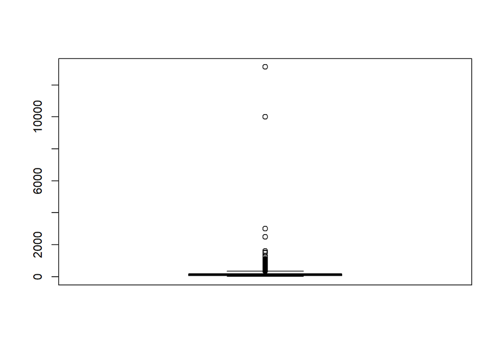

```r
boxplot(data$price)
test <- boxplot(data$price)
```

```r
min(test$out)
```

```
## [1] 350
```

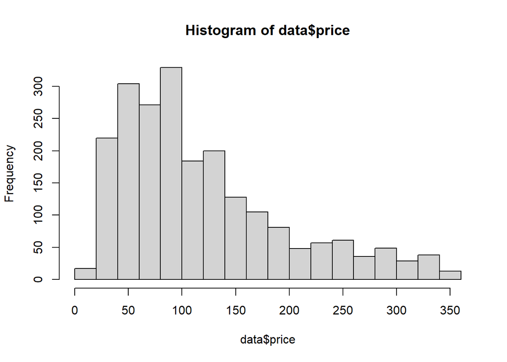

```r
# Le boxplot recommande de rejeter toutes observations d'au moins 350, il s'agit de données extrêmes.

data <- data[which(data$price < 350),]
hist(data$price) # Transformation par le logarithme pourrait être utile.
```

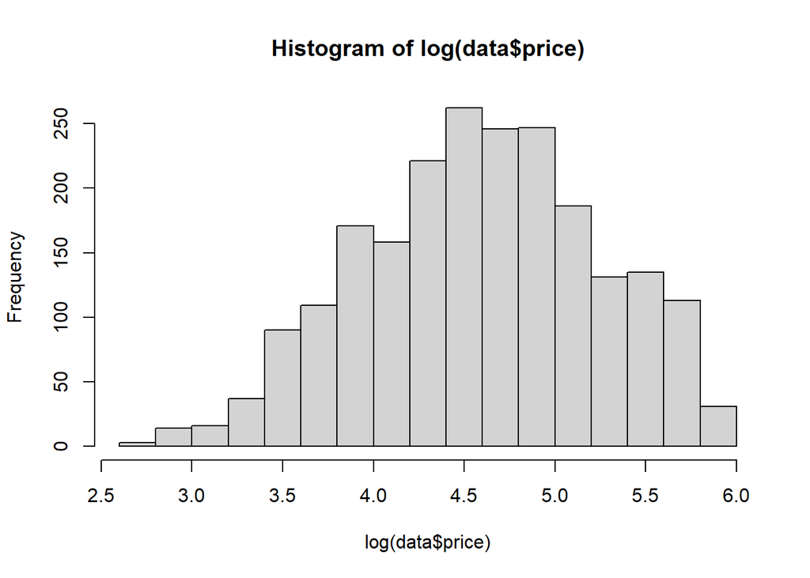

```r
hist(log(data$price))
```

Vérification entre la corrélation des variables numériques.

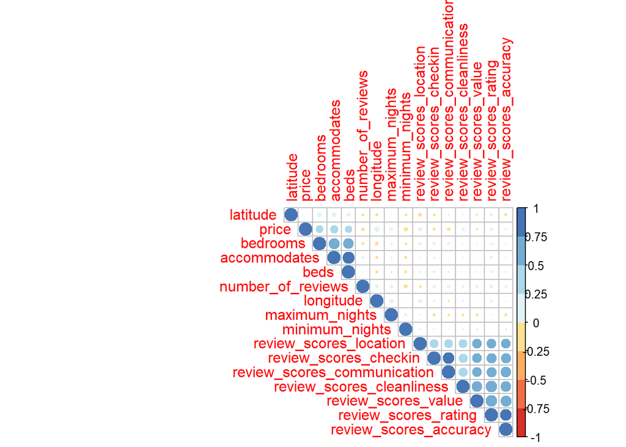

```r
correlation <-cor(data[,c(1,2,5,7:19)],use = "pairwise.complete.obs")
corrplot(correlation, type="upper", order="hclust",
         col=brewer.pal(n=8, name="RdYlBu"))
```

```r
# Légère corrélation entre le prix et certaines variables (Nombre de chambres, nombre de lits et nombre de personnes accueillies)
```

Regroupement du nombre de salles de bains en 3 catégories pour faciliter l’utilisation de la variable, sois : 1 et moins, ]1,2], plus de 2.

```r
table(data$bathrooms_text)
```

```
##
##          0 baths   0 shared baths           1 bath   1 private bath
##                2                2             1498              120
##    1 shared bath        1.5 baths 1.5 shared baths         10 baths
##              236              107               20                1
##         13 baths  13 shared baths          2 baths   2 shared baths
##                2               16              127                8
##        2.5 baths 2.5 shared baths          3 baths   3 shared baths
##               18                6                1                1
##        3.5 baths        Half-bath
##                4                1
```

```r
data$bathrooms_text <- ifelse(data$bathrooms_text == "Half-bath",0.5,vapply(strsplit(data$bathrooms_text," "), `[`, 1, FUN.VALUE=character(1)))

data$bathrooms_text <- cut(as.numeric(data$bathrooms_text),breaks = c(0,1,2,Inf),
                           labels = c("1 et moins","]1,2]","plus de 2"))
table(data$bathrooms_text)
```

```
##
## 1 et moins      ]1,2]  plus de 2
##       1855        262         49
```

# Préparation des jeux de données

Suppression des données manquantes et séparation en jeu d’entrainement et de test 80/20.

```r
data <- data[complete.cases(data[,-3]),-3]
set.seed(42)
sample <- sample(length(data[,1]),0.8*length(data[,1]))
train <- data[sample,]
test <- data[-sample,]
```

Création d’une fonction min/max pour normaliser les données numériques selon le jeu d’entrainement.

```r
min_max <- function(column_index_to_scale,df,df_use_to_scale){
  for (index in column_index_to_scale){
    min <- min(df_use_to_scale[,index],na.rm = T)
    max <- max(df_use_to_scale[,index],na.rm = T)
    scaled <-  (df[,index]-min)/(max-min)
    df[,index] <- scaled
  }
  return(df)
}
test <- min_max(c(1,2,4,6,7,9:18),test,train)
train <- min_max(c(1,2,4,6,7,9:18),train,train)
```

Création d’index pour effectuer une validation croisée avec 10 folder lors de l’entrainement.

```r
set.seed(42)
index <- kfold(train,10)
```

# Modélisation d’une forêt aléatoire

Effectuée en utilisant la RMSE(Root mean squared error) pour choisir les hyperparamètres selon une recherche par grille. L’optimisation est fait pour le choix du nombre d’arbres, de la profondeur maximale et du critère de séparation des arbres.

```r
min_rmse <- Inf
info <- c()
for (i in seq(1,15,1)){
  for (j in seq(1,701,50)){
    for (split in c("extratrees","variance")){
      rmse_pred <- NULL
      for (k in 1:10){
        list <- which(index == k)

        model <- ranger(price ~ .,data = train[-list,], num.trees = j,
                           max.depth = i,importance = "impurity", splitrule = split )

        prediction<- predict(model,train[list,])$predictions

        rmse_pred <- c(rmse_pred,round(sqrt(mean((prediction-train$price[list])^2)),4))

      }

      rmse_mat <- mean(rmse_pred)
      if (rmse_mat < min_rmse){
        info <- c(i,j,split,rmse_mat)
        min_rmse <- rmse_mat
      }
    }
  }
}
# Résultats obtenus : max.depth = 13, num.trees = 251, splitrule = variance
```

Modèle final

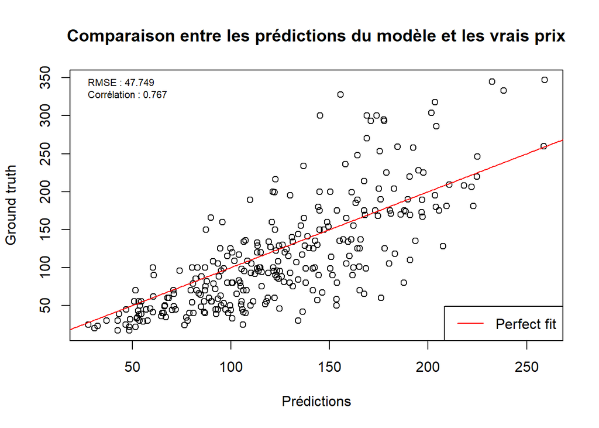

```r
set.seed(42)
model <- ranger(price ~ .,data = train, num.trees = 251,
                           max.depth = 13,importance = "impurity", splitrule = "variance")

importance <- as.data.frame(ranger::importance(model))


#Vérification pour trouver le meilleur modèle en supprimant tour à tour les variables moins importantes

min_rmse <- Inf
last_feature <- c("latitude")
for (tresh in seq(0,0.15,0.00001)){
  feature <- rownames(importance)[which((importance[,1])/sum(importance[,1]) > tresh)]
  if (length(feature) == length(last_feature) || length(feature) < 1){
    next()
  }
  last_feature <- feature
  for (forest in 1:5){
    model_test <- ranger(price ~ .,data = train[,c(feature,"price")], num.trees = 251,
                      max.depth = 13,importance = "impurity", splitrule = "variance")

    prediction <- predict(model_test,test)$prediction
    if (sqrt(mean((prediction-test$price)^2)) < min_rmse ){
      model <- model_test
      min_rmse <- sqrt(mean((prediction-test$price)^2))
    }

  }
}

prediction <- predict(model,test)$prediction

plot(prediction,test$price,xlab ="Prédictions",ylab = "Ground truth",
     main = "Comparaison entre les prédictions du modèle et les vrais prix")
legend("topleft", legend=c(paste0("RMSE : ",round(sqrt(mean((prediction-test$price)^2)),3)),
                             paste0("Corrélation : ",round(cor(prediction,test$price),3))),pt.cex = 1,cex = 0.7,bty = "n")
lines(-1000:100000,-1000:100000,col ="red")
legend("bottomright",legend = "Perfect fit",lty = 1,col = "red")
```

# Analyse

On remarque que la longitude et la latitude sont les variables les plus importantes pour prédire le prix. On gagnerait peut-être à faire du clustering sur ces données. De plus, on semble tendre à surestimer les locations avec les prix les plus faibles, c’est souvent ce qui arrive lorsque la distribution est de forme log-normale. Le modèle pourrait sans doute être amélioré, mais on y retrouve déjà une corrélation respectable entre les prédictions et les vrais prix.

```r
print(importance)
```

```
##                             ranger::importance(model)
## latitude                                     761497.4
## longitude                                    922621.0
## room_type                                    489119.2
## accommodates                                 668917.8
## bathrooms_text                               156618.5
## bedrooms                                     612892.5
## beds                                         497833.4
## minimum_nights                               495781.7
## maximum_nights                               171072.7
## number_of_reviews                            346184.5
## review_scores_rating                         267317.0
## review_scores_accuracy                       225148.0
## review_scores_cleanliness                    283703.6
## review_scores_checkin                        251973.7
## review_scores_communication                  209986.7
## review_scores_location                       322275.9
## review_scores_value                          235198.1
```